# Predicting Problem Drinking using Socio-Economic Factors

# Introduction

## The Data

NSDUH is a population based survey developed to gather information about substance abuse prevalence and determinants by drawing a nationally representative sample of individuals 12 years and older. Details of the study in 2014 can be found [here](https://www.samhsa.gov/data/sites/default/files/NSDUH-FRR1-2014/NSDUH-FRR1-2014.pdf) or [here](https://www.samhsa.gov/data/sites/default/files/NSDUH-DetTabs2014/NSDUH-DetTabs2014.pdf). Raw data of this study can be found [here](http://www.icpsr.umich.edu/icpsrweb/DSDR/studies/36361#datasetsSection). The original file contains 3148 variables and 55271 observations.

## Alcohol Use

The observed outcome for this analysis **alcbin** (originally *BINGEHVY*) is a composite variable created by examination of past month Binge Alcohol Use (*BINGEDRK*), past month Heavy Alcohol Use (*HVYDRK2*) and past month alcohol use (*ALCMON*). Binge Alcohol Use is defined as drinking five or more drinks on the same occasion (i.e., at the same time or within a couple of hours of each other) on at least 1 day in the past 30 days. Heavy Alcohol Use is defined as drinking five or more drinks on the same occasion on each of 5 or more days in the past 30 days; all heavy alcohol users are also binge alcohol users. IN NSDUH, a “drink” is defined as a can or bottle of beer, a glass of wine or a wine cooler, a shot of liquor, or a mixed drink with liquor in it. Times when respondents only had a sip or two from a drink are not considered to be alcohol consumption.

In 2014, 139.7 million Americans aged 12 or older reported current use of alcohol, 60.9 million reported binge alcohol use in the past month, and 16.3 million reported heavy alcohol use in the past month. Thus slightly more than 2 in 5 current alcohol users reported binge alcohol use (43.6 percent), and about 1 in 9 current alcohol users reported heavy alcohol use (11.7 percent). Among binge heavy alcohol users, more than 1 in 4 (26.8 percent) were heavy users.

## Measurement Items

Covariates assessed in this report were age, race, income, self-reported health, education attainment, marital status, gender, insurance coverage and an indicator of psychological distress. Almost all variables were dichotomized for analysis to avoid quasi-separation of data within the model due to low cell frequency as well as ease of interpretation.

The indicator of psychological distress **k6**, being the only quantitative predictor, is a composite measure based on the Kessler-6 psychological distress scale. Respondents to the NSDUH survey were asked to rank their experience with feelings of sadness, restlessness and hopelessness as some of the time or all of the time. These score were used to develop a major psychological distress scale of 0-24. In the survey, participants were asked to score the last 30 days (*K6SCMON*) as well as the worst 30 days in the last year (*K6SCMAX*). The highest score between these 2 months was used in the analysis.

## Loading Necessary Packages

```r
# Load Required Packages
library(stringr)  # Deal with string
library(tidyverse)  # General Purpose Data Cleaning
library(forcats)  # Deal with factors
library(caTools)  # Stratified sample split
source("common.R")
```

## Importing Data

The original file contains 3148 variables and 55271 observations. I did the data cleaning manually and wrote the output into a csv file (details of this process can be found in my repository on Github). The resulting data frame now consists of 31 variables and 41405 observations. We now will go ahead and perform strafied split of the data into training and testing set using *caTools* package.

```r
alchol <- data.frame(read_csv("alcohol2.csv"), check.names = FALSE)

# Split into training and testing sets
set.seed(1234)
split = sample.split(alchol$alcbin, SplitRatio = 0.7)
train = subset(alchol, split == TRUE)
test = subset(alchol, split == FALSE)
```

```r
# Process data frame with utility function
df_train <- prepare_dataset(train)
df_test <- prepare_dataset(test)
df_full <- rbind(df_test, df_train)
```

## Summary Statistic

Time to look at the data.

```r
head(df_full, 20)
```

```
       age       inc      race               educat         health
1    Other > $20,000 Non-white   Highschool or Less Good/Excellent
2    Other < $20,000 Non-white Highschool & Greater Good/Excellent
3    Other > $20,000     White Highschool & Greater Good/Excellent
4    Other > $20,000     White Highschool & Greater Good/Excellent
5    Other > $20,000 Non-white   Highschool or Less Good/Excellent
6    Other > $20,000     White   Highschool or Less      Fair/Poor
7    Other > $20,000     White Highschool & Greater Good/Excellent
      maristat insured gender k6 alcbin
1  Not Married     Yes Female 24      0
2  Not Married      No Female 16      0
3      Married     Yes   Male  2      1
4      Married     Yes Female  0      0
5      Married     Yes   Male  9      1
6      Married      No   Male 18      0
7      Married     Yes   Male  0      1
 [ reached getOption("max.print") -- omitted 13 rows ]
```

```r
str(df_full)
```

```
'data.frame':   41405 obs. of  10 variables:
 $ age     : Factor w/ 2 levels "18 - 25","Other": 2 2 2 2 2 2 2 1 2 2 ...
 $ inc     : Factor w/ 2 levels "> $20,000","< $20,000": 1 2 1 1 1 1 1 1 1 2 ...
 $ race    : Factor w/ 2 levels "White","Non-white": 2 2 1 1 2 1 1 1 1 2 ...
 $ educat  : Factor w/ 2 levels "Highschool & Greater",..: 2 1 1 1 2 2 1 1 1 2 ...
 $ health  : Factor w/ 2 levels "Good/Excellent",..: 1 1 1 1 1 2 1 1 1 1 ...
 $ maristat: Factor w/ 2 levels "Not Married",..: 1 1 2 2 2 2 2 2 2 1 ...
 $ insured : Factor w/ 2 levels "Yes","No": 1 2 1 1 1 2 1 1 1 1 ...
 $ gender  : Factor w/ 2 levels "Male","Female": 2 2 1 2 1 1 1 2 1 2 ...
 $ k6      : int  24 16 2 0 9 18 0 8 1 0 ...
 $ alcbin  : Factor w/ 2 levels "0","1": 1 1 2 1 2 1 2 1 1 1 ...
```

```r
summary(df_full)
```

```
      age               inc               race
 18 - 25:12914   > $20,000:32238   White    :25874
 Other  :28491   < $20,000: 9167   Non-white:15531




                  educat                 health             maristat
 Highschool & Greater:23395   Good/Excellent:36675   Not Married:23675
 Highschool or Less  :18010   Fair/Poor     : 4730   Married    :17730




 insured        gender            k6         alcbin
 Yes:30592   Male  :19258   Min.   : 0.000   0:29132
 No :10813   Female:22147   1st Qu.: 1.000   1:12273
                            Median : 4.000
                            Mean   : 5.558
                            3rd Qu.: 8.000
                            Max.   :24.000
```

We have 10 variables as mentioned in previous section: 1 outcome varible (**alcbin**) and 9 covariates.

# Classification

There are many possible classification techniques that one might use to predict a qualitative response. In this section we will discuss three widely used classifiers: *logistic regression, linear discriminant analysis and quadratic discriminant analysis*

Logistic regression utilizes *maximum likelihood* to fit its model. The estimates coefficients of the independent variables are chosen to maximize the likelihood function.

```r
glm_alcbin = glm(alcbin ~ age + race + inc + health + educat + maristat + gender +
    insured + k6, data = df_train, family = "binomial")
summary(glm_alcbin)
```

```
Call:
glm(formula = alcbin ~ age + race + inc + health + educat + maristat +
    gender + insured + k6, family = "binomial", data = df_train)

Deviance Residuals:
    Min       1Q   Median       3Q      Max
-1.4398  -0.8626  -0.6645   1.2258   2.2030

Coefficients:
                          Estimate Std. Error z value Pr(>|z|)
(Intercept)              -0.039193   0.036293  -1.080 0.280183
ageOther                 -0.262777   0.031380  -8.374  < 2e-16 ***
raceNon-white            -0.256869   0.028847  -8.905  < 2e-16 ***
inc< $20,000             -0.050258   0.034694  -1.449 0.147439
healthFair/Poor          -0.330624   0.045801  -7.219 5.25e-13 ***
educatHighschool or Less -0.110257   0.028461  -3.874 0.000107 ***
maristatMarried          -0.495149   0.031404 -15.767  < 2e-16 ***
genderFemale             -0.839194   0.027106 -30.960  < 2e-16 ***
insuredNo                 0.049605   0.033089   1.499 0.133843
k6                        0.024501   0.002336  10.490  < 2e-16 ***
---
Signif. codes:  0 '***' 0.001 '**' 0.01 '*' 0.05 '.' 0.1 ' ' 1

(Dispersion parameter for binomial family taken to be 1)

    Null deviance: 35232  on 28983  degrees of freedom
Residual deviance: 33450  on 28974  degrees of freedom
AIC: 33470

Number of Fisher Scoring iterations: 4
```

Based on the p-values, there are strong evidences of an association between **alcbin** and *age, race, health, education attainment, marital status, gender* and *k6 score* while the opposite applies to *income* and *insurance coverage*.

We will now go on to calculate the area under the graph (AUC) of the Receiver Operating Curve (ROC) for the glm model based on the training data.

```r
library(ROCR)  # ROC plots and parameters

glm_predTrain = predict(glm_alcbin, type = "response")
glm_ROCRpredTrain = prediction(glm_predTrain, df_train$alcbin)
glm_ROCRperfTrain = performance(glm_ROCRpredTrain, "tpr", "fpr")
glm_aucTrain = as.numeric(performance(glm_ROCRpredTrain, "auc")@y.values)
```

The model scores an AUC of 0.6554504 . We’ll now time to apply the model onto the test set and see how accurate its predictions are.

```r
glm_predTest = predict(glm_alcbin, df_test, type = "response")
with(df_test, table(alcbin, glm_predTest > 0.5))
```

```
alcbin FALSE TRUE
     0  8443  296
     1  3336  346
```

We obtain an accuracy of 0.708 from the above confusion matrix. How about the AUC value of the ROC for the model applied on the test set?

```r
glm_ROCRpredTest = prediction(glm_predTest, df_test$alcbin)
glm_ROCRperfTest = performance(glm_ROCRpredTest, "tpr", "fpr")
glm_auc = as.numeric(performance(glm_ROCRpredTest, "auc")@y.values)
```

So GLM model achieves an AUC value of 0.6500116. Below is a visualization of the ROC curve.

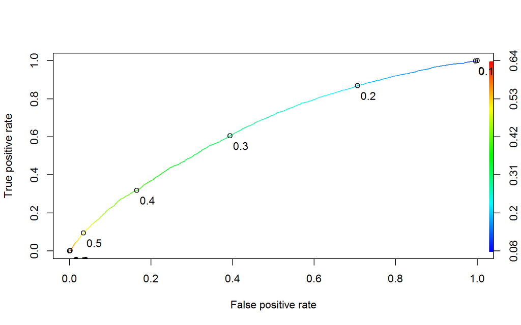

```r
plot(glm_ROCRperfTest, colorize = TRUE, print.cutoffs.at = seq(0, 1, by = 0.1),
    text.adj = c(-0.2, 1.7))
```

## Linear Discriminant Analysis

While Logistic Regression involves directly modelling Pr(Y=k|X=x) using the logistic function, Linear Discriminant Analysis (LDA) models the distribution of the predictos X separately in each of the response classes (given Y), and then use Bayes’ theorem to flip these around into estimates for Pr(Y=k|X=x). LDA has several advantages over logistic regression:

- When the class are well-separated, the parameter estimates for the logistic regression model are surprisingly unstable. Linear discriminant analysis does not suffer from this problem.
- If n is small and the distribution of the predictors X is approximately normal in each of the class, the LDA model is again more stable than the logistic regression model.
- LDA is also more popular when we have more than two response classes (i.e. if we retained the original 4 values of the outcome variable **alcbin**)

We now will go ahead and implement LDA onto our training set.

```r
library(MASS)
library(class)

# Linear Discriminant Analysis
lda_alcbin = lda(alcbin ~ age + race + inc + educat + health + maristat + insured +
    gender + k6, data = df_train)
lda_alcbin
```

```
Call:
lda(alcbin ~ age + race + inc + educat + health + maristat +
    insured + gender + k6, data = df_train)

Prior probabilities of groups:
        0         1
0.7035951 0.2964049

Group means:
   ageOther raceNon-white inc< $20,000 educatHighschool or Less
0 0.7217673     0.3863090    0.2174766                0.4356887
1 0.6101734     0.3433826    0.2277965                0.4302177
  healthFair/Poor maristatMarried insuredNo genderFemale       k6
0      0.12416025       0.4707988 0.2558721    0.5920659 5.298926
1      0.09277151       0.3338377 0.2687696    0.3983238 6.124083

Coefficients of linear discriminants:
                                 LD1
ageOther                 -0.51664893
raceNon-white            -0.45792455
inc< $20,000             -0.10091292
educatHighschool or Less -0.19305722
healthFair/Poor          -0.56584638
maristatMarried          -0.88221693
insuredNo                 0.08515250
genderFemale             -1.54887276
k6                        0.04512642
```

The *predict()* function then returns a list with 3 elements of which *class* provides LDA’s predictions about **alcbin**.

```r
lda_predTest = predict(lda_alcbin, df_test)
lda_class = lda_predTest$class
table(lda_class, df_test$alcbin)
```

```
lda_class    0    1
        0 8415 3303
        1  324  379
```

```r
lda_ROCRpredTest = prediction(lda_predTest$posterior[, 2], df_test$alcbin)
lda_ROCRperfTest = performance(lda_ROCRpredTest, "tpr", "fpr")
lda_auc = as.numeric(performance(lda_ROCRpredTest, "auc")@y.values)
```

LDA achieves an AUC value of 0.6501348 which is a little higher than that of glm model.

## Quadratic Discriminant Analysis

Quadratic Discriminant Analysis (QDA) is an extension of LDA in which the QDA classifiers results from assuming that the observations from each class are drawn from a Gaussian distribution, and plugging estimates for the parameters into Bayes’ theorem in order to perform prediction. However, unlike LDA, QDA assumes each class has its own covariance matrix. Due to this LDA is a much less flexible classifier than QDA and so has substantially lower variance. On the other hand, QDA can benefit from lower bias, especially if the training set if very large.

```r
# Quadratic Discriminant Analysis
qda_alcbin = qda(alcbin ~ age + race + educat + health + maristat + insured +
    gender + k6, data = df_train)
qda_alcbin
```

```
Call:
qda(alcbin ~ age + race + educat + health + maristat + insured +
    gender + k6, data = df_train)

Prior probabilities of groups:
        0         1
0.7035951 0.2964049

Group means:
   ageOther raceNon-white educatHighschool or Less healthFair/Poor
0 0.7217673     0.3863090                0.4356887      0.12416025
1 0.6101734     0.3433826                0.4302177      0.09277151
  maristatMarried insuredNo genderFemale       k6
0       0.4707988 0.2558721    0.5920659 5.298926
1       0.3338377 0.2687696    0.3983238 6.124083
```

```r
qda_predTest = predict(qda_alcbin, df_test)
qda_class = predict(qda_alcbin, df_test)$class
table(qda_class, df_test$alcbin)
```

```
qda_class    0    1
        0 7983 2965
        1  756  717
```

```r
qda_ROCRpredTest = prediction(qda_predTest$posterior[, 2], df_test$alcbin)
qda_ROCRperfTest = performance(qda_ROCRpredTest, "tpr", "fpr")
qda_auc = as.numeric(performance(qda_ROCRpredTest, "auc")@y.values)
```

QDA achieves an accuracy rate of 0.7004267, similar to that of LDA’s and AUC of 0.6505942, the highest out of our 3 binary classification models so far.

## More on Logistic Regression

You can determine the significance of a logistic regression model by looking at the difference between the model’s deviance on the training data, and the null deviance (the deviance of the best constant model: the mean of y). In R tongue, if your glm model is called *model* then you want to look at *delta_deviance = model$null.deviance - model$deviance*. If there is no signal, then this quantity is distributed as a chi-square distribution with degrees of freedom equal to the difference of the degrees of freedom of each model (*delta_deviance* will have one degree of freedom for every numerical input to the model, and *k-1* degrees of freedom for every k-level categorical variable). The area under the right tail of this chi-squared distribution is the probability that no-signal data would produce *delta_deviance* as large as what you observed. This is the significance value of model. We create some utility functions to extract these values:

```r
get_significance = function(model) {
    delta_deviance = model$null.deviance - model$deviance
    df = model$df.null - model$df.residual
    sig = pchisq(delta_deviance, df, lower.tail = FALSE)
}

get_chiscores = function(dframe, varnames) {
    nvar = length(varnames)
    scores = numeric(nvar)
    for (i in seq_len(nvar)) {
        model = glm(paste("alcbin~", varnames[i]), dframe, family = binomial(link = "logit"))
        scores[i] = get_significance(model)
    }

    sframe = data.frame(var = varnames, scores = scores, stringsAsFactors = FALSE)
    sframe
}

varnames = setdiff(colnames(df_train), "alcbin")
sframe = get_chiscores(df_train, varnames)
```

From this we can heuristically determine which variables have signal for a classification model by looking for variables with small significance value (as estimated by the chi-square distribution). The way we define “small” is by picking a threshold, and accepting variables whose significance value is smaller than that threshold. Most modeling algorithms can handle the presence of a few noise variables, so it’s better to pick a somewhat high threshold to err on the side of accepting useless variables, rather than losing useful ones. The graph below show variable scores(significance). The threshold is shown as the dashed red line; the variables that fell below the threshold are shown in green.

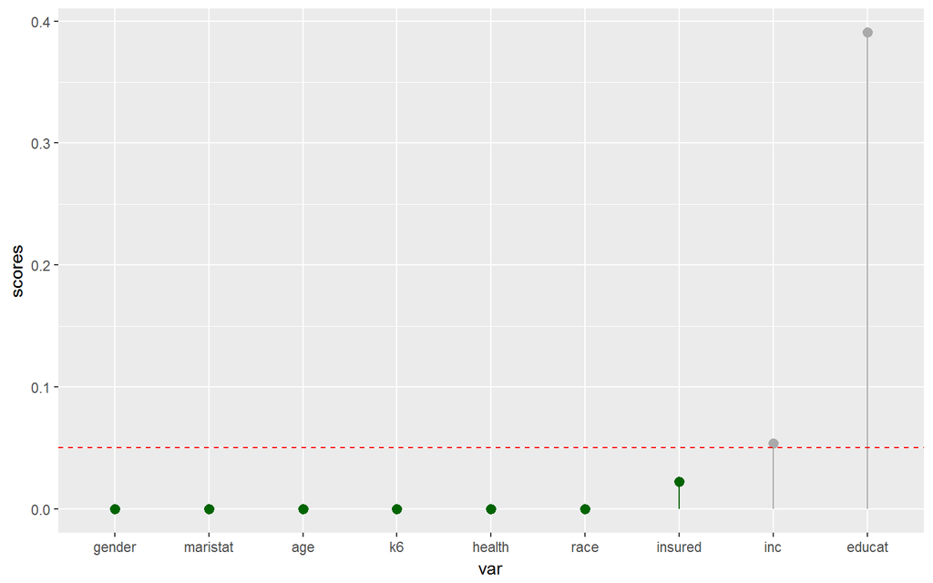

```r
scoreplot = function(frm, threshold, sort = 1) {
    n = dim(frm)[1]
    frm$var = reorder(frm$var, frm$scores * sort, FUN = sum)
    frm$goodvar = frm$scores < threshold

    ggplot(frm, aes(x = var, y = scores, ymin = 0, ymax = scores, color = goodvar)) +
        geom_pointrange() + geom_hline(yintercept = threshold, color = "red",
        linetype = 2) + scale_color_manual(values = c(`TRUE` = "darkgreen",
        `FALSE` = "darkgray")) + theme(legend.position = "none")
}

threshold = 0.05
scoreplot(sframe, threshold)
```

# Resampling Method

Resampling Method involves repeatedly drawing samples from a training set and refitting a model of interest on each sample in order to obtain additional information about the fitted model. For example, in order to estimate the variability of a linear regression fit, we can repeatedly draw different samples from the training data, fit a linear regression to each new sample, and then examine the extent to which the resulting fits differ. Such an approach may allow us to obtain information that would not be available from fitting the model only once during the original training sample. In this section, I will discuss 2 very commonly used resampling cross-validation, more specifically k-fold Cross-Validation and Leave-p-Out Cross-Validation (LpO CV). I will then showcase an application of Leave-p-Out Cross-Validation on our training set using logistic regression model.

## k-Fold Cross Validation

An alternative to LOOCV is k-fold CV. This approaches involves randomly dividing the set of observations into k groups, or *folds*, of approximately equal size. The first fold is treated as a validation set, and the method is fit on the remaining k - 1 folds. The mean squared error, MSE<sub>1</sub> is then computed on the observations in the held-out fold. This procedure is repeated k times; each time, a different group of observations is treated as a validation set. This process results in *k* estimates of the test error, MSE<sub>1</sub>, MSE<sub>2</sub>,…,MSE<sub>k</sub>. The k-fold CV estimate is computed by averageing these values.

## Leave-p-Out Cross Validation

LpO CV involves using p observations as the validation set and the remaining observations as the training set. The statistical learning method is fit on these n-p training observations and a prediction p is made for the excluded p observations. The process is then repeated for the next p observations until a complete iteration has been run throughout our data set. Below is a utility function to perform leave 100 out Cross Validation on our training set.

```r
log_reg <- function(df, size = 100) {
    N <- nrow(df)
    size = 100

    df <- df[sample(N), ]

    num <- floor(N/size)
    rest <- N - num * size
    ncv <- cumsum(c(rep(size, num), rest))

    predictions <- data.frame(alcbin = df$alcbin, pred = NA)

    for (n in ncv) {
        v <- rep(TRUE, N)
        v[(n - size + 1):n] <- FALSE

        lr <- glm(alcbin ~ age + race + inc + educat + health + maristat + insured +
            gender + k6, data = df[v, ], family = binomial(logit))
        predictions[!v, "pred"] <- predict(lr, newdata = df[!v, ], type = "response")
    }
    return(predictions)
}
```

We proceed to apply this function and obtain the usual model diagnostic metrics.

```r
loocv_pred <- log_reg(df_train, size = 100)
summary(loocv_pred)
```

```
 alcbin         pred
 0:20393   Min.   :0.08407
 1: 8591   1st Qu.:0.20193
           Median :0.28635
           Mean   :0.29640
           3rd Qu.:0.36954
           Max.   :0.64615
```

```r
with(loocv_pred, table(alcbin, pred > 0.5))
```

```
alcbin FALSE  TRUE
     0 19660   733
     1  7815   776
```

```r
ROCRpred100pCV = prediction(loocv_pred$pred, loocv_pred$alcbin)
ROCRperf100pCV = performance(ROCRpred100pCV, "tpr", "fpr")
L100pCV_auc = as.numeric(performance(ROCRpred100pCV, "auc")@y.values)
```

Note that after Cross Validation is applied on our glm model of the training set, the accuracy remains at 0.706 but the AUC value of 0.6543184 is a bit of a dip from 0.6554504 Based on this evaluation, we can be more confident at how well this classifier will do when asked to make prediction on the testing set (which in fact it did quite well).

## More on ROC, AUC and Threshold Value

Not all diagnostic tests or classifiers return a simple “yes-or-no” answer. In fact, most probably don’t. Generally, a classification or diagnostic procedure will return a score along a continuum; ideally, the positive instances score towards one end of the scale, and the negative examples towards the other end. It is up to the analyst to set a threshold on that score that separates what is considered a positive result from what is considered a negative result. The receiver Operating Characteristic Curve, or *ROC Curve*, is a tool that helps set the best threshold.

Let’s have a look at the distribution of response values of the outcome variable **alcbin** on the predicted probabilities.

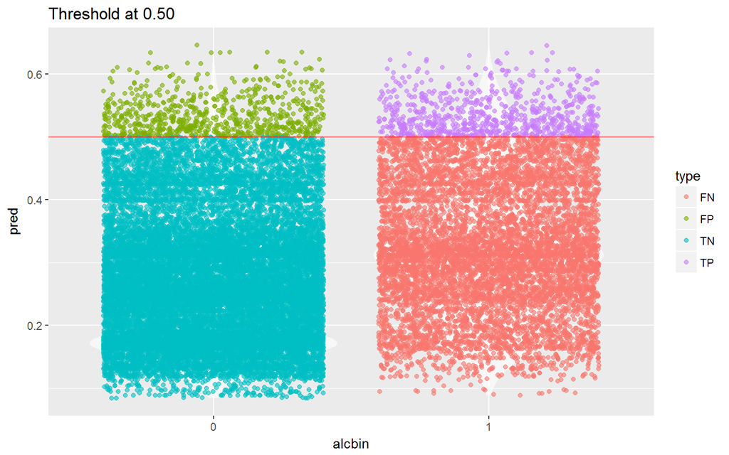

```r
# Visualize Prediction
plot_pred_type_distribution <- function(df, threshold) {
    v <- rep(NA, nrow(df))
    v <- ifelse(df$pred >= threshold & df$alcbin == 1, "TP", v)
    v <- ifelse(df$pred >= threshold & df$alcbin == 0, "FP", v)
    v <- ifelse(df$pred < threshold & df$alcbin == 1, "FN", v)
    v <- ifelse(df$pred < threshold & df$alcbin == 0, "TN", v)

    df$pred_type <- v

    ggplot(data = df, aes(x = alcbin, y = pred)) + geom_violin(fill = rgb(1,
        1, 1, alpha = 0.6), color = NA) + geom_jitter(aes(color = pred_type),
        alpha = 0.6) + geom_hline(yintercept = threshold, color = "red", alpha = 0.6) +
        scale_color_discrete(name = "type") + labs(title = sprintf("Threshold at %.2f",
        threshold))
}

plot_pred_type_distribution(loocv_pred, 0.5)
```

This plot illustrates the tradeoff we face upon choosing a reasonable threshold. If we increase the threshold, the number of false positive (FP) is lowered while the number of false negative (FN) results increase.

The ROC curve was introduced for the purpose of visualizing and quantifying the impact of a threshold on the FP/FN tradeoff.

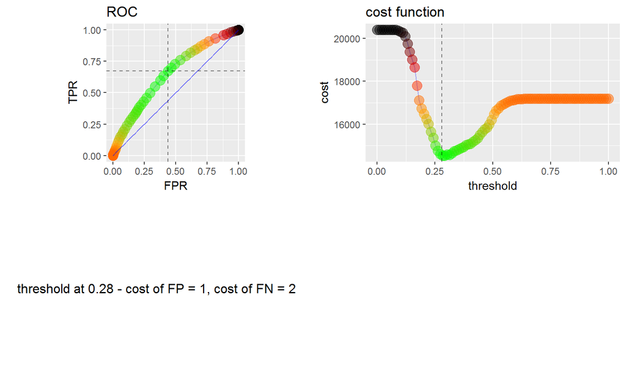

```r
library(gridExtra)
library(grid)

calculate_roc <- function(df, cost_of_fp, cost_of_fn, n = 100) {
    tpr <- function(df, threshold) {
        sum(df$pred >= threshold & df$alcbin == 1)/sum(df$alcbin == 1)
    }

    fpr <- function(df, threshold) {
        sum(df$pred >= threshold & df$alcbin == 0)/sum(df$alcbin == 0)
    }

    cost <- function(df, threshold, cost_of_fp, cost_of_fn) {
        sum(df$pred >= threshold & df$alcbin == 0) * cost_of_fp + sum(df$pred <
            threshold & df$alcbin == 1) * cost_of_fn
    }

    roc <- data.frame(threshold = seq(0, 1, length.out = n), tpr = NA, fpr = NA)
    roc$tpr <- sapply(roc$threshold, function(th) tpr(df, th))
    roc$fpr <- sapply(roc$threshold, function(th) fpr(df, th))
    roc$cost <- sapply(roc$threshold, function(th) cost(df, th, cost_of_fp,
        cost_of_fn))

    return(roc)
}

roc <- calculate_roc(loocv_pred, 1, 2, n = 100)

# Plot ROC curve for the above distribution
plot_roc <- function(roc, threshold, cost_of_fp, cost_of_fn) {

    norm_vec <- function(v) (v - min(v))/diff(range(v))

    idx_threshold = which.min(abs(roc$threshold - threshold))

    col_ramp <- colorRampPalette(c("green", "orange", "red", "black"))(100)
    col_by_cost <- col_ramp[ceiling(norm_vec(roc$cost) * 99) + 1]
    p_roc <- ggplot(roc, aes(fpr, tpr)) + geom_line(color = rgb(0, 0, 1, alpha = 0.3)) +
        geom_point(color = col_by_cost, size = 4, alpha = 0.5) + coord_fixed() +
        geom_line(aes(threshold, threshold), color = rgb(0, 0, 1, alpha = 0.5)) +
        labs(title = sprintf("ROC")) + xlab("FPR") + ylab("TPR") + geom_hline(yintercept = roc[idx_threshold,
        "tpr"], alpha = 0.5, linetype = "dashed") + geom_vline(xintercept = roc[idx_threshold,
        "fpr"], alpha = 0.5, linetype = "dashed")

    p_cost <- ggplot(roc, aes(threshold, cost)) + geom_line(color = rgb(0, 0,
        1, alpha = 0.3)) + geom_point(color = col_by_cost, size = 4, alpha = 0.5) +
        labs(title = sprintf("cost function")) + geom_vline(xintercept = threshold,
        alpha = 0.5, linetype = "dashed")

    sub_title <- sprintf("threshold at %.2f - cost of FP = %d, cost of FN = %d",
        threshold, cost_of_fp, cost_of_fn)

    grid.arrange(p_roc, p_cost, ncol = 2, sub = textGrob(sub_title, gp = gpar(cex = 1),
        just = "bottom"))
}

plot_roc(roc, 0.28, 1, 2)
```

The dashed line indicates the location of the (FPR,TPR) corresponding to a threshold of 0.28 which seems to be the optimal threshold based on the associated cost. Note that here I assume a cost of 1 for FP cases and a cost of 2 for FN cases.

# Feature Selection

Machine Learning uses features (variables or attributes) to generate predictive models. Too many features may lead to a series of pitfalls such as over-fitting or agonizingly expensive computation. Feature Selection Methods can be used to identify and remove redundant attributes from data that do not contribute to the accuracy of a predictive model. There are various techniques that one can use to subset feature space and enable models to perform better and more efficiently. In this section I’m going to examinine the basics of wrapper methods followed by one of its implementation using Boruta algorithm on Random Forest models.

## Wrapper Method

In wrapper Method, we try to use a subset of features and train a model using them. Based on the inferences that we draw from the previous model, we decide to add or remove features from our subset.

We’ll start with loading a required list of libraries.

```r
library(Metrics)
library(randomForest)
```

We start by applying randomForest call similar to our earlier binary classification model

```r
set.seed(123)
model_rf <- randomForest(alcbin ~ age + race + inc + educat + health + maristat +
    insured + gender + k6, data = df_train)

preds <- predict(model_rf, df_test[, -10])
```

This gives us an accuracy of 0.6362454 on the test set. The *importance()* calls show us the MeanDecreaseGini which measures the average gain of purity by splits of a given variable. We will select the top 6 features to rebuild the forest.

```r
randomForest::importance(model_rf)
```

```
         MeanDecreaseGini
age             117.44218
race             81.69149
inc              54.49834
educat           72.36835
health           56.68399
maristat        157.51114
insured          63.78400
gender          379.70748
k6              305.70044
```

```r
model_rf2 <- randomForest(alcbin ~ age + race + educat + maristat + gender +
    k6, data = df_train)

preds2 <- predict(model_rf2, df_test[, -10])
```

The rebuilt forest achives an AUC of0.659288

## Boruta Algorithm

[Boruta](https://www.jstatsoft.org/article/view/v036i11) works as a wrapper algorithm around Random Forest. It iteratively removes the features which are proved by a statistical test to be less relevant than random probes.

First we will load the package and examine how it works.

```r
library(Boruta)

set.seed(123)
boruta.train <- Boruta(alcbin ~ ., data = df_train, doTrace = 2, maxRuns = 25)
print(boruta.train)
```

```
Boruta performed 10 iterations in 9.503596 mins.
 9 attributes confirmed important: age, educat, gender, health,
inc and 4 more;
 No attributes deemed unimportant.
```

While we wait for all the completion of all iterations (it might take a while seeing we are using a relatively large data set), below are the parameters used in Boruta:

- *maxRuns*: maximal number of random forest runs. You can consider increasing this parameter if tentative attributes are left. Default is 100.
- *doTrace*: It refers to verbosity level. 0 means no tracing. 1 means reporting attribute decision as soon as it is cleared. 2 means all of 1 plus additionally reporting each iteration. Default is 0
- *holdHistory*: The full history of importance runs is stored if set to TRUE (Default). Gives a plot of Classifier run vs. Importance when the plotImpHistory function is called.

Once the command finishes running, we will take a look at the Boruta variable importance chart.

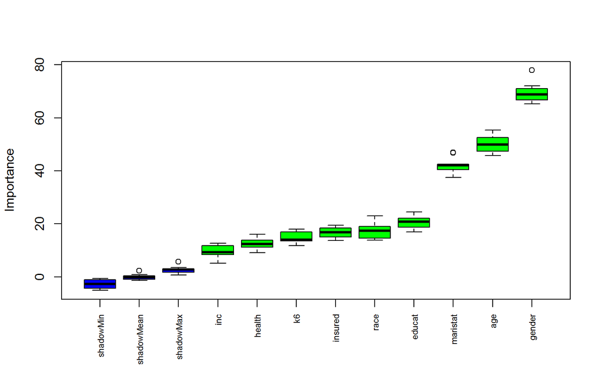

```r
plot(boruta.train, xlab = "", xaxt = "n")
lz <- lapply(1:ncol(boruta.train$ImpHistory), function(i) boruta.train$ImpHistory[is.finite(boruta.train$ImpHistory[,
    i]), i])
names(lz) <- colnames(boruta.train$ImpHistory)
Labels <- sort(sapply(lz, median))
axis(side = 1, las = 2, labels = names(Labels), at = 1:ncol(boruta.train$ImpHistory),
    cex.axis = 0.7)
```

All variables are deemed important. However if there are tentative attributes, they will be classified as confirmed or rejected by comparing the median Z score of the attributes with the median Z score of the best shadow attribute. We can take a decision on them with the following command:

```r
final.boruta <- TentativeRoughFix(boruta.train)
print(final.boruta)
```

```
Boruta performed 10 iterations in 9.503596 mins.
 9 attributes confirmed important: age, educat, gender, health,
inc and 4 more;
 No attributes deemed unimportant.
```

We then obtain the list of confirmed attributes

```r
getSelectedAttributes(final.boruta, withTentative = F)
```

```
[1] "age"      "inc"      "race"     "educat"   "health"   "maristat"
[7] "insured"  "gender"   "k6"
```

```r
boruta.df <- attStats(final.boruta)
print(boruta.df)
```

```
           meanImp medianImp    minImp   maxImp normHits  decision
age      50.283778 49.968417 45.838087 55.37400        1 Confirmed
inc       9.389766  9.228925  5.035506 12.60956        1 Confirmed
race     17.440234 17.404032 13.765355 23.00471        1 Confirmed
educat   20.448995 20.726381 16.879097 24.43530        1 Confirmed
health   12.567875 12.398608  9.096295 16.01936        1 Confirmed
maristat 42.245409 42.046745 37.413310 46.98029        1 Confirmed
insured  16.789193 16.856069 13.674557 19.49223        1 Confirmed
gender   69.505552 68.784934 65.304356 77.94243        1 Confirmed
k6       14.865357 13.948039 11.709756 17.91037        1 Confirmed
```

# Tree-Based Methods

Decision trees can be used for both regression and classification. A *classification tree* is very similar to a regression tree, except that it is used to predict a qualitative response rather than a quantitative one. In classification tree, we predict that each observation belongs to the most commonly occuring class of training observations in the region to which it belongs. In interpreting the results of a classification tree, we are often interested not only in the class prediction corresponding to a particular terminal node region, but also in the *class proportions* among the training observfations that fall into that region.

The process of building regression tree involves a top-down, greedy approach known as recursive binary partitioning. This algorithm iteratively repeat 2 steps for every generated node realizing a split:

- Determine a covariate to split at
- Determine a split within the set of values of that covariate

Decision trees have a number of advantages over the more classical approaches discussed in previous section. They are easier to explain to people. Some believe that trees more closely mirror human decision-making than do say logistic regression. On the other hand, trees generally do not have the same level of predictive accuracy by themselves as some other approaches. Additionally, trees can be very non-robust. A small change in data can cause a large change in the final estimated tree.

However these shortcomings can be limited using Cross-Validation and methods like *bagging, random forests* and *boosting*. In the following subsection, we will discuss a few of these.

## Decision Trees using R Package **party**

What sets **party** apart from the majority of traditional recursive partitioning algorithms is that these approaches favor optimizing an information measure and, according to *Mingers* (1987)

> have no concept of statistical significance, and so cannot distinguish between a significant and an insignificant improvement in the information measure.

The **party** package, according to *White and Liu* (1994), demands for

> a statistical approach [to recursve partitioning] which takes into account the distributional properties of the measure

The following is an example of its implementation. First, to find a good tree, I performed a 100-fold cross validation grid search on five settings of *party::ctree()*:

- testtype in {Bonferroni, Univariate, Teststatistic}
- teststat in {quad}
- mincriterion in {90%, 95%, 99%}
- minsplit in {60, 40, 20, 10}
- minbucket in {30, 20, 10, 5}
- maxdepth in {0, 4, 5, 6}

Although MonteCarlo was among one of the possible testtype argument option, it simply added too much time to the execution time so I decided to drop it. The following series of functions set up the parameters of the CV

```r
# Utility Functions
read_data <- function(df_train, df_test, shuffle = FALSE) {

    df_full <- rbind(df_train, df_test)

    # homogenize levels
    df_train <- df_full[1:nrow(df_train), ]
    df_test <- df_full[(nrow(df_train) + 1):nrow(df_full), ]

    if (shuffle) {
        df_train <- df_train[sample(nrow(df_train)), ]
        df_test <- df_test[sample(nrow(df_test)), ]
    }

    list(train = df_train, test = df_test)
}

kfolds <- function(N, k) {
    return(sort(rep(1:k, ceiling(N/k))[1:N]))
}

hypergrid <- function(k, tt, minc, mins, minb, maxd, shuffle = FALSE) {
    G <- expand.grid(tt = tt, minc = minc, mins = mins, minb = minb, maxd = maxd,
        k = 1:k, stringsAsFactors = FALSE)
    G <- G[G$mins > G$minb, ]

    if (shuffle) {
        G <- G[sample(nrow(G)), ]
    }

    return(G)
}

gridsearch_ctree <- function(K, G, data, formula, cores = 6, maxIter = NA) {
    library(doSNOW, quietly = TRUE)

    cl <- makeCluster(cores)
    registerDoSNOW(cl)

    if (is.na(maxIter)) {
        nIter <- nrow(G)
    } else {
        nIter <- maxIter
    }

    res <- foreach(i = 1:nIter, .packages = "party", .combine = "rbind") %dopar%
        {
            if (i%%100 == 0)
                cat(sprintf("%d of %d", i, nrow(G)), file = "state.txt")

            cfg <- G[i, ]
            ctrl <- ctree_control(testtype = cfg$tt, mincriterion = cfg$minc,
                minsplit = cfg$mins, minbucket = cfg$minb, maxdepth = cfg$maxd)

            data_train <- data[K != cfg$k, ]
            data_test <- data[K == cfg$k, ]

            res <- data.frame(testtype = cfg$tt, mincriterion = cfg$minc, minsplit = cfg$mins,
                minbucket = cfg$minb, maxdepth = cfg$maxd, correct = NA, incorrect = NA,
                elapsed = NA, terminals = NA)

            try({
                time <- system.time(t <- ctree(formula, data_train, controls = ctrl))
                predictions <- Predict(t, data_test)

                response <- all.vars(formula)[1]

                nc <- sum(predictions == data_test[, response])

                res <- data.frame(testtype = cfg$tt, mincriterion = cfg$minc,
                  minsplit = cfg$mins, minbucket = cfg$minb, maxdepth = cfg$maxd,
                  correct = nc, incorrect = length(predictions) - nc, elapsed = time["elapsed"],
                  terminals = length(unique(where(t))))
            })

            return(res)
        }

    stopCluster(cl)

    return(res)
}
```

Using these, we prepare the data for the search

```r
data <- read_data(df_train, df_test, shuffle = TRUE)

k <- 100

K <- kfolds(nrow(data$train), k)
G <- hypergrid(k, tt = c("Bonferroni", "Univariate", "Teststatistic"), minc = c(0.9,
    0.95, 0.99), mins = c(60, 40, 20, 10), minb = c(30, 20, 10, 5), maxd = c(0,
    4, 5, 6), shuffle = TRUE)
```

Finally we can carry out the Cross-Validation

```r
result <- NA

library(party)

for (i in 1:44) {
    subG <- G[((i - 1) * 900 + 1):(i * 900), ]
    print(sprintf("G from %d to %d", ((i - 1) * 900 + 1), i * 900))

    subResult <- gridsearch_ctree(K, subG, data$train, alcbin ~ age + race +
        inc + health + educat + maristat + gender + insured + k6, cores = 6,
        maxIter = NA)

    if (!is.na(result)) {
        result <- rbind(result, subResult)
    } else {
        result <- subResult
    }

    save.image("ctree.grid.search.RData")
}
```

Note that this process can take up to hours. Once it finishes we proceed to analyze the result

```r
load("ctree.grid.search.RData")

library(sqldf)

r <- sqldf("select testtype, mincriterion, minsplit, minbucket, maxdepth,
           sum(correct) as N1, sum(incorrect) as N0, sum(elapsed) as Time,
           sum(terminals) as Term, count(correct) as N from result group by testtype,
           mincriterion, minsplit, minbucket, maxdepth")

r$err <- r$N0/(r$N0 + r$N1)

r <- r[order(r$err), ]
r$idx <- 1:nrow(r)
head(r)

r$testtype <- as.character(r$testtype)

v <- rep(NA, nrow(r))

require(party)

for (i in 1:nrow(r)) {
    t <- ctree(alcbin ~ age + race + inc + health + educat + maristat + gender +
        insured + k6, data$train, controls = ctree_control(teststat = "quad",
        testtype = r[i, "testtype"], mincriterion = r[i, "mincriterion"], minsplit = r[i,
            "minsplit"], minbucket = r[i, "minbucket"], maxdepth = r[i, "maxdepth"]))

    v[i] <- sum(t@predict_response() != data$train$alcbin)/nrow(data$train)
}

r$err_all <- v
```

At this point we should obtain a table of combination of settings ranked by errors. We can go ahead and plot the winning tree.

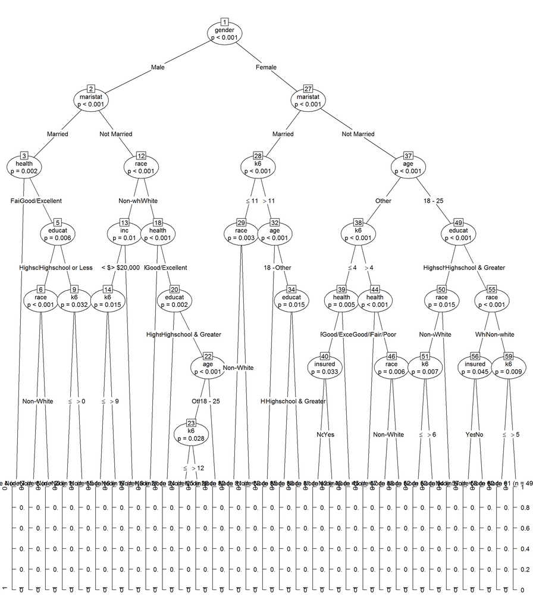

```r
library(e1071)  # Misc Statistical functions
library(doSNOW)  # Multi-cores processing
require(party)

cl <- makeCluster(6, type = "SOCK")
registerDoSNOW(cl)
tree <- ctree(alcbin ~ ., data = df_train, controls = ctree_control(teststat = "quad",
    testtype = "Bonferroni", mincriterion = 0.95, minsplit = 10, minbucket = 5,
    maxdepth = 0))
stopCluster(cl)

plot(tree)
```

Now we’ll see if **party**’s *ctree* gives us a more accurate prediction on the test set

```r
ctree_predTest <- Predict(tree, df_test)
table(df_test$alcbin, ctree_predTest)
```

```
   ctree_predTest
       0    1
  0 8537  202
  1 3402  280
```

Based on the confusion matrix, *ctree* achieves an accuracy of 0.7098462. The auc can be calculated via

```r
require(ROCR)
ctree_predProb <- predict(tree, newdata = df_test, type = "prob")
ctree_predProb <- unlist(lapply(ctree_predProb, function(el) el[2]))

ROCRpredCtree = prediction(ctree_predProb, df_test$alcbin)
ROCRperfCtree = performance(ROCRpredCtree, "tpr", "fpr")
as.numeric(performance(ROCRpredCtree, "auc")@y.values)
```

```
[1] 0.6513159
```

# References

- Mingers J (1987). “Expert Systems – Rule Induction with Statistical Data.” *Journal of the Operations Research Society*, **38**(1), 39–47.
- White AP, Liu WZ (1994). “Bias in Information-based Measures in Decision Tree Induction.” *Machine Learning*, **15**, 321–329.
- https://cran.r-project.org/web/packages/party/vignettes/party.pdf

Binh Nguyen

2017-08-17